# Regression Analysis

- Show All Code
- Hide All Code
- View Source

Author

Alexis Alberto Zúñiga Alonso

Published

October 2, 2026

## 1. Introduction

### 1.1. Project Libraries and Installation

```r
# Project libraries
libs <- c("genridge", "tidyverse", "skimr", "corrplot", "car",
          "lmtest", "glmnet", "MASS", "performance", "see", "gt", "psych")

# Install only the missing ones
missing <- setdiff(libs, rownames(installed.packages()))
if (length(missing) > 0) {
  install.packages(missing, repos = "https://cloud.r-project.org")
}

# Load all of them
invisible(lapply(libs, library, character.only = TRUE))
```

### 1.2. Dataset Analysis

#### 1.2.1. Importing the dataset

The dataset to be used in this activity will be `prostate` from the `genridge` library. This dataset contains the following structure:

```r
# Information about the library
library(genridge)
?prostate
```

#### 1.2.2. Dataset

```r
# Dataframe creation
data(prostate, package="genridge")
df <- prostate |> dplyr::select(-train)
# Stringify dataset
str(df)
```

```
'data.frame':   97 obs. of  9 variables:
 $ lcavol : num  -0.58 -0.994 -0.511 -1.204 0.751 ...
 $ lweight: num  2.77 3.32 2.69 3.28 3.43 ...
 $ age    : int  50 58 74 58 62 50 64 58 47 63 ...
 $ lbph   : num  -1.39 -1.39 -1.39 -1.39 -1.39 ...
 $ svi    : int  0 0 0 0 0 0 0 0 0 0 ...
 $ lcp    : num  -1.39 -1.39 -1.39 -1.39 -1.39 ...
 $ gleason: int  6 6 7 6 6 6 6 6 6 6 ...
 $ pgg45  : int  0 0 20 0 0 0 0 0 0 0 ...
 $ lpsa   : num  -0.431 -0.163 -0.163 -0.163 0.372 ...
```

```r
# Dataset summary
print(summary(df))
```

```
     lcavol           lweight           age             lbph
 Min.   :-1.3471   Min.   :2.375   Min.   :41.00   Min.   :-1.3863
 1st Qu.: 0.5128   1st Qu.:3.376   1st Qu.:60.00   1st Qu.:-1.3863
 Median : 1.4469   Median :3.623   Median :65.00   Median : 0.3001
 Mean   : 1.3500   Mean   :3.629   Mean   :63.87   Mean   : 0.1004
 3rd Qu.: 2.1270   3rd Qu.:3.876   3rd Qu.:68.00   3rd Qu.: 1.5581
 Max.   : 3.8210   Max.   :4.780   Max.   :79.00   Max.   : 2.3263
      svi              lcp             gleason          pgg45
 Min.   :0.0000   Min.   :-1.3863   Min.   :6.000   Min.   :  0.00
 1st Qu.:0.0000   1st Qu.:-1.3863   1st Qu.:6.000   1st Qu.:  0.00
 Median :0.0000   Median :-0.7985   Median :7.000   Median : 15.00
 Mean   :0.2165   Mean   :-0.1794   Mean   :6.753   Mean   : 24.38
 3rd Qu.:0.0000   3rd Qu.: 1.1787   3rd Qu.:7.000   3rd Qu.: 40.00
 Max.   :1.0000   Max.   : 2.9042   Max.   :9.000   Max.   :100.00
      lpsa
 Min.   :-0.4308
 1st Qu.: 1.7317
 Median : 2.5915
 Mean   : 2.4784
 3rd Qu.: 3.0564
 Max.   : 5.5829
```

```r
# Skim through the data
skimr::skim(df)
```

Data summary

| Name | df |
| --- | --- |
| Number of rows | 97 |
| Number of columns | 9 |
| _______________________ |  |
| Column type frequency: |  |
| numeric | 9 |
| ________________________ |  |
| Group variables | None |

**Variable type: numeric**

| skim_variable | n_missing | complete_rate | mean | sd | p0 | p25 | p50 | p75 | p100 | hist |
| --- | --- | --- | --- | --- | --- | --- | --- | --- | --- | --- |
| lcavol | 0 | 1 | 1.35 | 1.18 | -1.35 | 0.51 | 1.45 | 2.13 | 3.82 | ▃▅▇▆▃ |
| lweight | 0 | 1 | 3.63 | 0.43 | 2.37 | 3.38 | 3.62 | 3.88 | 4.78 | ▁▃▇▆▁ |
| age | 0 | 1 | 63.87 | 7.45 | 41.00 | 60.00 | 65.00 | 68.00 | 79.00 | ▁▁▅▇▂ |
| lbph | 0 | 1 | 0.10 | 1.45 | -1.39 | -1.39 | 0.30 | 1.56 | 2.33 | ▇▁▂▃▅ |
| svi | 0 | 1 | 0.22 | 0.41 | 0.00 | 0.00 | 0.00 | 0.00 | 1.00 | ▇▁▁▁▂ |
| lcp | 0 | 1 | -0.18 | 1.40 | -1.39 | -1.39 | -0.80 | 1.18 | 2.90 | ▇▂▂▂▂ |
| gleason | 0 | 1 | 6.75 | 0.72 | 6.00 | 6.00 | 7.00 | 7.00 | 9.00 | ▅▇▁▁▁ |
| pgg45 | 0 | 1 | 24.38 | 28.20 | 0.00 | 0.00 | 15.00 | 40.00 | 100.00 | ▇▂▂▁▁ |
| lpsa | 0 | 1 | 2.48 | 1.15 | -0.43 | 1.73 | 2.59 | 3.06 | 5.58 | ▁▅▇▃▁ |

```r
# Head of the dataset
print(head(df))
```

```
      lcavol  lweight age      lbph svi       lcp gleason pgg45       lpsa
1 -0.5798185 2.769459  50 -1.386294   0 -1.386294       6     0 -0.4307829
2 -0.9942523 3.319626  58 -1.386294   0 -1.386294       6     0 -0.1625189
3 -0.5108256 2.691243  74 -1.386294   0 -1.386294       7    20 -0.1625189
4 -1.2039728 3.282789  58 -1.386294   0 -1.386294       6     0 -0.1625189
5  0.7514161 3.432373  62 -1.386294   0 -1.386294       6     0  0.3715636
6 -1.0498221 3.228826  50 -1.386294   0 -1.386294       6     0  0.7654678
```

```r
# Tail of the dataset
print(tail(df))
```

```
     lcavol  lweight age       lbph svi       lcp gleason pgg45     lpsa
92 2.532903 3.677566  61  1.3480732   1 -1.386294       7    15 4.129551
93 2.830268 3.876396  68 -1.3862944   1  1.321756       7    60 4.385147
94 3.821004 3.896909  44 -1.3862944   1  2.169054       7    40 4.684443
95 2.907447 3.396185  52 -1.3862944   1  2.463853       7    10 5.143124
96 2.882564 3.773910  68  1.5581446   1  1.558145       7    80 5.477509
97 3.471966 3.974998  68  0.4382549   1  2.904165       7    20 5.582932
```

```r
# Shape / Dimensions of the Dataset
print(dim(df))
```

```
[1] 97  9
```

### 1.3. Descriptive Statistics

```r
# Descriptive statistics with psych
psych::describe(df) |>
  round(2) |>
  gt::gt(rownames_to_stub = TRUE)
```

|  | vars | n | mean | sd | median | trimmed | mad | min | max | range | skew | kurtosis | se |
| --- | --- | --- | --- | --- | --- | --- | --- | --- | --- | --- | --- | --- | --- |
| lcavol | 1 | 97 | 1.35 | 1.18 | 1.45 | 1.39 | 1.28 | -1.35 | 3.82 | 5.17 | -0.24 | -0.60 | 0.12 |
| lweight | 2 | 97 | 3.63 | 0.43 | 3.62 | 3.62 | 0.38 | 2.37 | 4.78 | 2.41 | 0.06 | 0.36 | 0.04 |
| age | 3 | 97 | 63.87 | 7.45 | 65.00 | 64.47 | 5.93 | 41.00 | 79.00 | 38.00 | -0.80 | 0.96 | 0.76 |
| lbph | 4 | 97 | 0.10 | 1.45 | 0.30 | 0.03 | 2.50 | -1.39 | 2.33 | 3.71 | 0.13 | -1.75 | 0.15 |
| svi | 5 | 97 | 0.22 | 0.41 | 0.00 | 0.15 | 0.00 | 0.00 | 1.00 | 1.00 | 1.36 | -0.16 | 0.04 |
| lcp | 6 | 97 | -0.18 | 1.40 | -0.80 | -0.34 | 0.87 | -1.39 | 2.90 | 4.29 | 0.71 | -1.01 | 0.14 |
| gleason | 7 | 97 | 6.75 | 0.72 | 7.00 | 6.67 | 0.00 | 6.00 | 9.00 | 3.00 | 1.22 | 2.36 | 0.07 |
| pgg45 | 8 | 97 | 24.38 | 28.20 | 15.00 | 20.57 | 22.24 | 0.00 | 100.00 | 100.00 | 0.94 | -0.37 | 2.86 |
| lpsa | 9 | 97 | 2.48 | 1.15 | 2.59 | 2.48 | 1.15 | -0.43 | 5.58 | 6.01 | 0.00 | 0.43 | 0.12 |

#### 1.3.1. Histograms

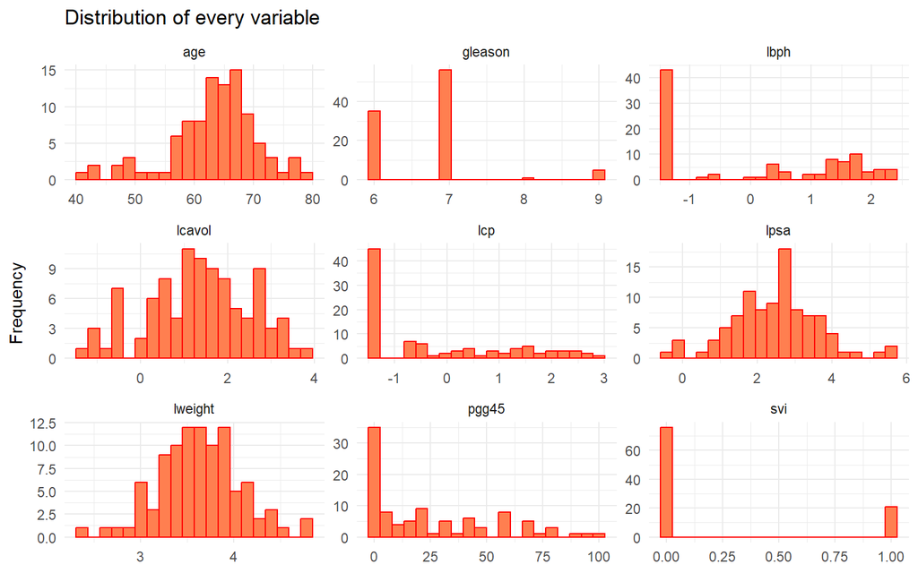

```r
df |>
  pivot_longer(everything(), names_to = "variable", values_to = "value") |>
  ggplot(aes(x = value)) +
  geom_histogram(bins = 20, fill = "coral", color = "red") +
  facet_wrap(~ variable, scales = "free") +
  labs(title = "Distribution of every variable", x = NULL, y = "Frequency") +
  theme_minimal()
```

#### 1.3.2 Normality Test

Shapiro-Wilk test for normality on the variables in the dataset.

```r
# Shapiro-Wilk on lcavol
shapiro.test(df$lcavol)
```

```
    Shapiro-Wilk normality test

data:  df$lcavol
W = 0.98295, p-value = 0.2414
```

```r
# Shapiro-Wilk on lweight
shapiro.test(df$lweight)
```

```
    Shapiro-Wilk normality test

data:  df$lweight
W = 0.9936, p-value = 0.929
```

```r
# Shapiro-Wilk on age
shapiro.test(df$age)
```

```
    Shapiro-Wilk normality test

data:  df$age
W = 0.94679, p-value = 0.0006376
```

```r
# Shapiro-Wilk on lbph
shapiro.test(df$lbph)
```

```
    Shapiro-Wilk normality test

data:  df$lbph
W = 0.79376, p-value = 2.454e-10
```

```r
# Shapiro-Wilk on svi
shapiro.test(df$svi)
```

```
    Shapiro-Wilk normality test

data:  df$svi
W = 0.50717, p-value < 2.2e-16
```

```r
# Shapiro-Wilk on lcp
shapiro.test(df$lcp)
```

```
    Shapiro-Wilk normality test

data:  df$lcp
W = 0.80618, p-value = 5.842e-10
```

```r
# Shapiro-Wilk on gleason
shapiro.test(df$gleason)
```

```
    Shapiro-Wilk normality test

data:  df$gleason
W = 0.70326, p-value = 1.049e-12
```

```r
# Shapiro-Wilk on pgg45
shapiro.test(df$pgg45)
```

```
    Shapiro-Wilk normality test

data:  df$pgg45
W = 0.82336, p-value = 2.065e-09
```

```r
# Shapiro-Wilk on lpsa
shapiro.test(df$lpsa)
```

```
    Shapiro-Wilk normality test

data:  df$lpsa
W = 0.98443, p-value = 0.3087
```

**Observations:**

- The variables that follow a **normal distribution** according to the results given by the Shapiro-Wilk test are: `lcavol`, `lweight`, and `lpsa`. The rest of variables **do not** follow a normal distribution.

### 1.4. Correlation Matrix

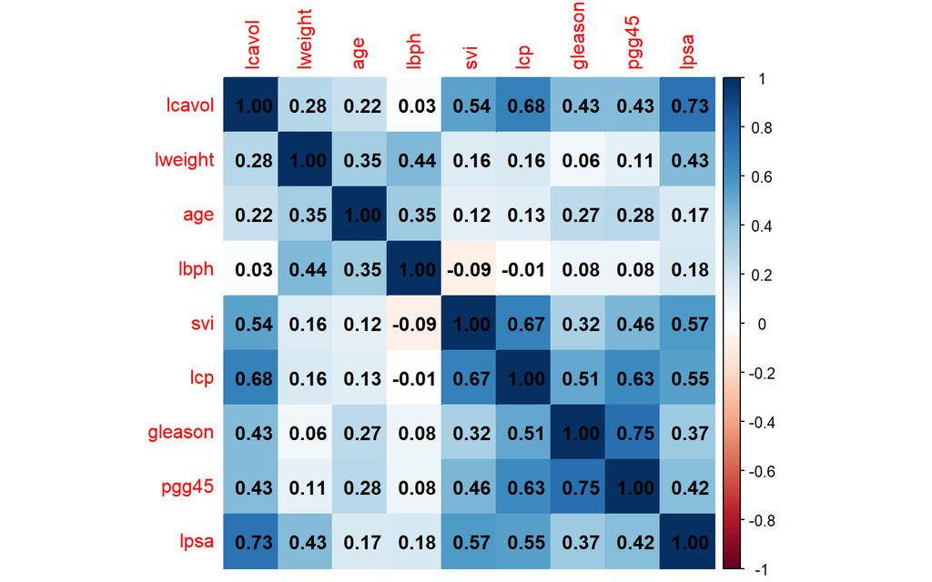

```r
corrplot(cor(df), method = "color", addCoef.col = "black")
```

## 2. Train / Test Split

The seed is fixed with `set.seed(123)` so the split is reproducible. 70% of the observations are used to train the models and the remaining 30% to evaluate their performance.

```r
set.seed(123)
idx   <- sample(nrow(df), 0.7 * nrow(df))
train <- df[idx, ]
test  <- df[-idx, ]

cat("Train:", nrow(train), "observations\n")
```

```
Train: 67 observations
```

```r
cat("Test: ", nrow(test), "observations\n")
```

```
Test:  30 observations
```

## 3. Multiple Linear Regression (Full Model)

`lpsa` is the response variable and all the other variables are predictors.

```r
full_model <- lm(lpsa ~ ., data = train)
summary(full_model)
```

```
Call:
lm(formula = lpsa ~ ., data = train)

Residuals:
     Min       1Q   Median       3Q      Max
-1.70137 -0.32901 -0.03892  0.43860  1.60677

Coefficients:
             Estimate Std. Error t value Pr(>|t|)
(Intercept) -1.193679   1.958227  -0.610  0.54453
lcavol       0.466150   0.105449   4.421 4.38e-05 ***
lweight      0.723549   0.261043   2.772  0.00748 **
age         -0.013025   0.014049  -0.927  0.35771
lbph         0.073486   0.067706   1.085  0.28225
svi          0.669491   0.292442   2.289  0.02572 *
lcp         -0.088718   0.111805  -0.794  0.43071
gleason      0.145557   0.216649   0.672  0.50434
pgg45        0.004901   0.005492   0.892  0.37587
---
Signif. codes:  0 '***' 0.001 '**' 0.01 '*' 0.05 '.' 0.1 ' ' 1

Residual standard error: 0.6956 on 58 degrees of freedom
Multiple R-squared:  0.6333,    Adjusted R-squared:  0.5827
F-statistic: 12.52 on 8 and 58 DF,  p-value: 3.096e-10
```

### 3.1. Multicollinearity (VIF)

```r
vif(full_model)
```

```
  lcavol  lweight      age     lbph      svi      lcp  gleason    pgg45
2.126434 1.379956 1.307110 1.293350 2.242169 3.231911 2.562448 3.034720
```

**Observations:**

- Only `lcavol`, `lweight` and `svi` are significant at the 5% level; the other predictors do not contribute significantly once the rest are in the model.
- The highest VIFs correspond to `lcp` and `pgg45`. No VIF is above 5, so multicollinearity is moderate, but the correlated predictors (`lcavol`–`lcp`, `gleason`–`pgg45`) justify applying variable selection methods.

## 4. Variable Selection Methods

### 4.1. Forward, Backward and Stepwise

All three methods use the AIC as the selection criterion. Forward and stepwise start from the null model (intercept only); backward starts from the full model.

```r
null_model <- lm(lpsa ~ 1, data = train)

forward_model  <- step(null_model, scope = formula(full_model),
                       direction = "forward", trace = 0)
backward_model <- step(full_model, direction = "backward", trace = 0)
stepwise_model <- step(null_model, scope = formula(full_model),
                       direction = "both", trace = 0)

formula(forward_model)
```

```
lpsa ~ lcavol + lweight + svi + gleason
```

```r
formula(backward_model)
```

```
lpsa ~ lcavol + lweight + svi + pgg45
```

```r
formula(stepwise_model)
```

```
lpsa ~ lcavol + lweight + svi + gleason
```

### 4.2. Lasso, Ridge and Elastic Net

`glmnet` requires a numeric matrix of predictors. The penalty parameter $\lambda$ is chosen with 10-fold cross-validation (`cv.glmnet`), using the value that minimizes the cross-validation error (`lambda.min`). The seed is set before each call so the folds are reproducible.

- **Lasso:** $\alpha = 1$
- **Ridge:** $\alpha = 0$
- **Elastic Net:** $\alpha = 0.5$

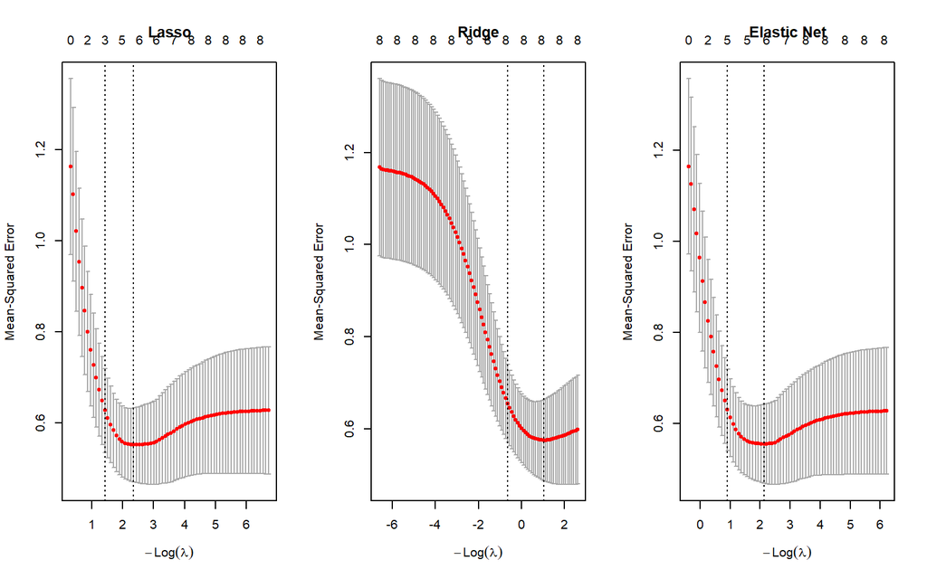

```r
x_train <- model.matrix(lpsa ~ ., data = train)[, -1]
y_train <- train$lpsa
x_test  <- model.matrix(lpsa ~ ., data = test)[, -1]

set.seed(123)
lasso_cv <- cv.glmnet(x_train, y_train, alpha = 1)
set.seed(123)
ridge_cv <- cv.glmnet(x_train, y_train, alpha = 0)
set.seed(123)
enet_cv  <- cv.glmnet(x_train, y_train, alpha = 0.5)

par(mfrow = c(1, 3))
plot(lasso_cv, main = "Lasso")
plot(ridge_cv, main = "Ridge")
plot(enet_cv,  main = "Elastic Net")
```

```r
par(mfrow = c(1, 1))
```

Coefficients of each penalized model (a coefficient of 0 means the variable was eliminated):

```r
penalized_coefs <- cbind(
  as.matrix(coef(lasso_cv, s = "lambda.min")),
  as.matrix(coef(ridge_cv, s = "lambda.min")),
  as.matrix(coef(enet_cv,  s = "lambda.min"))
)
colnames(penalized_coefs) <- c("Lasso", "Ridge", "Elastic Net")
round(penalized_coefs, 4)
```

```
              Lasso   Ridge Elastic Net
(Intercept) -0.8405 -1.3571     -1.2444
lcavol       0.3815  0.3034      0.3720
lweight      0.5490  0.5913      0.5941
age          0.0000 -0.0009      0.0000
lbph         0.0000  0.0439      0.0156
svi          0.4705  0.4754      0.5007
lcp          0.0000  0.0462      0.0000
gleason      0.1023  0.1781      0.1373
pgg45        0.0017  0.0028      0.0022
```

## 5. Model Comparison (RMSE and MAE)

All models are evaluated on the **test set**, which was not used during training.

```r
rmse <- function(y, pred) sqrt(mean((y - pred)^2))
mae  <- function(y, pred) mean(abs(y - pred))

predictions <- list(
  "Full model"  = predict(full_model, test),
  "Forward"     = predict(forward_model, test),
  "Backward"    = predict(backward_model, test),
  "Stepwise"    = predict(stepwise_model, test),
  "Lasso"       = as.numeric(predict(lasso_cv, x_test, s = "lambda.min")),
  "Ridge"       = as.numeric(predict(ridge_cv, x_test, s = "lambda.min")),
  "Elastic Net" = as.numeric(predict(enet_cv,  x_test, s = "lambda.min"))
)

metrics <- tibble(
  Model = names(predictions),
  RMSE  = map_dbl(predictions, function(p) rmse(test$lpsa, p)),
  MAE   = map_dbl(predictions, function(p) mae(test$lpsa, p))
)

metrics |>
  arrange(RMSE) |>
  gt() |>
  fmt_number(columns = c(RMSE, MAE), decimals = 4)
```

| Model | RMSE | MAE |
| --- | --- | --- |
| Full model | 0.7422 | 0.5332 |
| Backward | 0.7665 | 0.5776 |
| Elastic Net | 0.7980 | 0.5857 |
| Lasso | 0.7994 | 0.5755 |
| Forward | 0.8011 | 0.6153 |
| Stepwise | 0.8011 | 0.6153 |
| Ridge | 0.8261 | 0.6136 |

**Observations:**

- Among the variable selection methods, **Backward** has the lowest RMSE, and its MAE is practically tied with Lasso’s (difference smaller than 0.003). It is therefore the method with the best overall performance, and it is the model analyzed in the next section.
- The full model obtains slightly lower errors than all the selection methods. With only 30 test observations these differences are small; Backward achieves similar performance with half of the predictors (`lcavol`, `lweight`, `svi`, `pgg45`), which makes it simpler to interpret.

## 6. Analysis of the Best Model (Backward)

```r
best_model <- backward_model
summary(best_model)
```

```
Call:
lm(formula = lpsa ~ lcavol + lweight + svi + pgg45, data = train)

Residuals:
     Min       1Q   Median       3Q      Max
-1.65921 -0.41224 -0.07317  0.44640  1.53256

Coefficients:
             Estimate Std. Error t value Pr(>|t|)
(Intercept) -1.003776   0.810811  -1.238  0.22039
lcavol       0.426077   0.086718   4.913 6.87e-06 ***
lweight      0.736437   0.226935   3.245  0.00189 **
svi          0.531448   0.250011   2.126  0.03752 *
pgg45        0.005802   0.003595   1.614  0.11161
---
Signif. codes:  0 '***' 0.001 '**' 0.01 '*' 0.05 '.' 0.1 ' ' 1

Residual standard error: 0.6893 on 62 degrees of freedom
Multiple R-squared:  0.6152,    Adjusted R-squared:  0.5903
F-statistic: 24.78 on 4 and 62 DF,  p-value: 2.795e-12
```

### 6.1. Significance of the Model (ANOVA and F Statistic)

- $H_0$: all the coefficients of the predictors are equal to zero.
- $H_1$: at least one coefficient is different from zero.

```r
anova(best_model)
```

```
Analysis of Variance Table

Response: lpsa
          Df Sum Sq Mean Sq F value    Pr(>F)
lcavol     1 36.397  36.397 76.6139 1.975e-12 ***
lweight    1  5.275   5.275 11.1031  0.001457 **
svi        1  4.173   4.173  8.7831  0.004309 **
pgg45      1  1.238   1.238  2.6049  0.111611
Residuals 62 29.455   0.475
---
Signif. codes:  0 '***' 0.001 '**' 0.01 '*' 0.05 '.' 0.1 ' ' 1
```

```r
f <- summary(best_model)$fstatistic
p_value <- pf(f["value"], f["numdf"], f["dendf"], lower.tail = FALSE)
cat("F =", round(f["value"], 3), "on", f["numdf"], "and", f["dendf"],
    "DF,  p-value =", signif(p_value, 3), "\n")
```

```
F = 24.776 on 4 and 62 DF,  p-value = 2.79e-12
```

**Observations:** the p-value of the F statistic is far below 0.05, so $H_0$ is rejected: the model is globally significant. In the ANOVA table, `lcavol`, `lweight` and `svi` are significant, while `pgg45` is not significant at the 5% level, although the AIC kept it in the model.

### 6.2. Assumption Checks

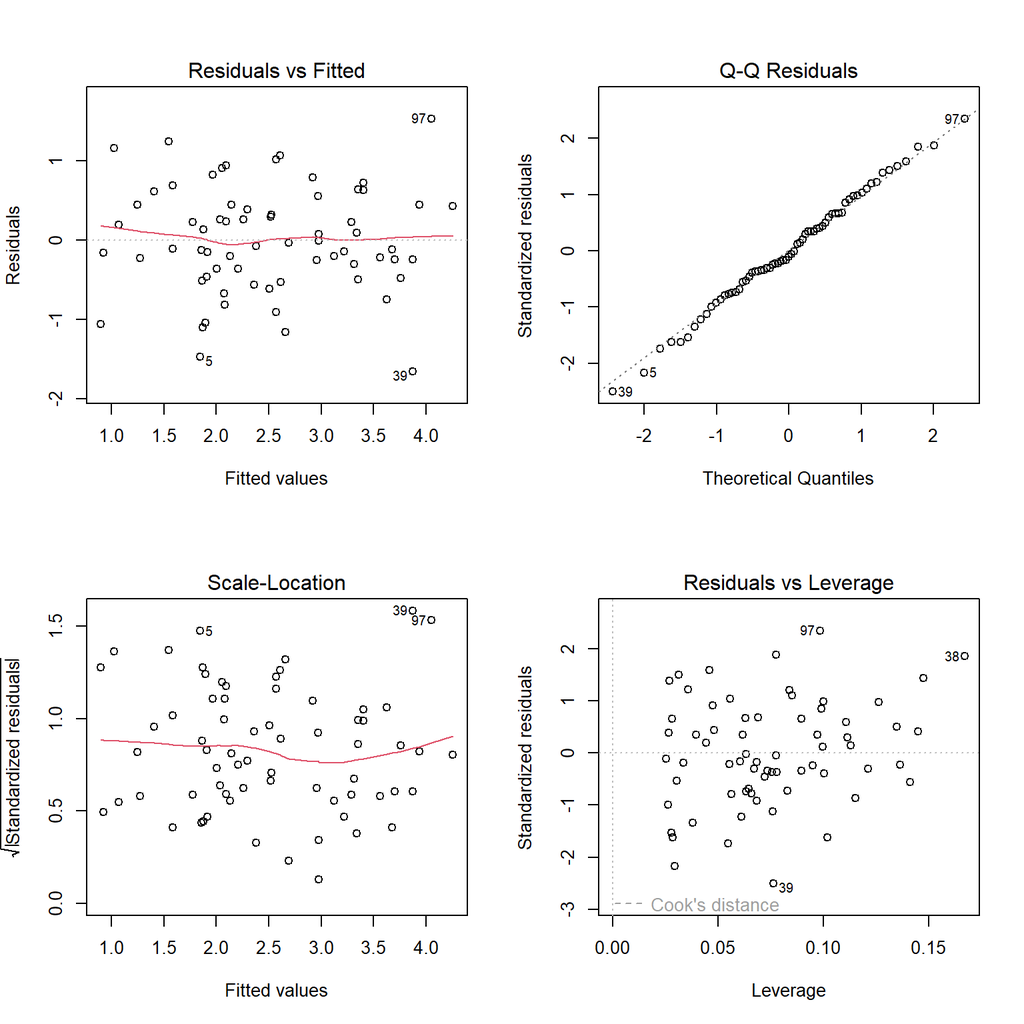

```r
par(mfrow = c(2, 2))
plot(best_model)
```

```r
par(mfrow = c(1, 1))
```

#### 6.2.1. Normality of the Residuals

- $H_0$: the residuals follow a normal distribution.
- $H_1$: the residuals do not follow a normal distribution.

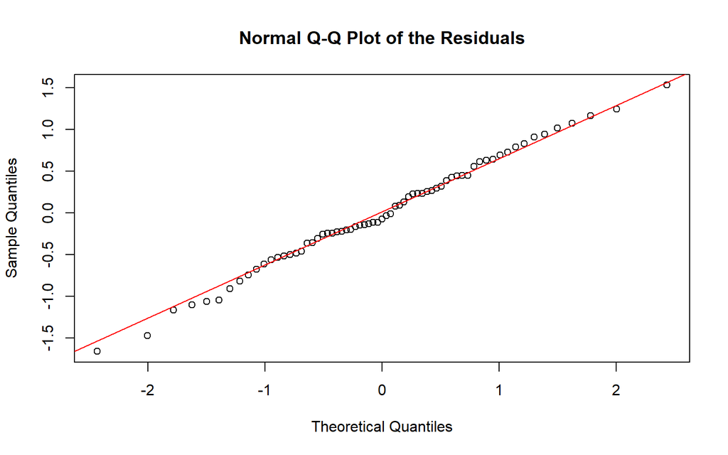

```r
qqnorm(residuals(best_model), main = "Normal Q-Q Plot of the Residuals")
qqline(residuals(best_model), col = "red")
```

```r
shapiro.test(residuals(best_model))
```

```
    Shapiro-Wilk normality test

data:  residuals(best_model)
W = 0.99391, p-value = 0.9862
```

**Observations:** the points of the Q-Q plot follow the reference line and the p-value of the Shapiro-Wilk test is greater than 0.05, so $H_0$ is not rejected: there is no evidence against the normality of the residuals.

#### 6.2.2. Homoscedasticity

- $H_0$: the variance of the residuals is constant (homoscedasticity).
- $H_1$: the variance of the residuals is not constant (heteroscedasticity).

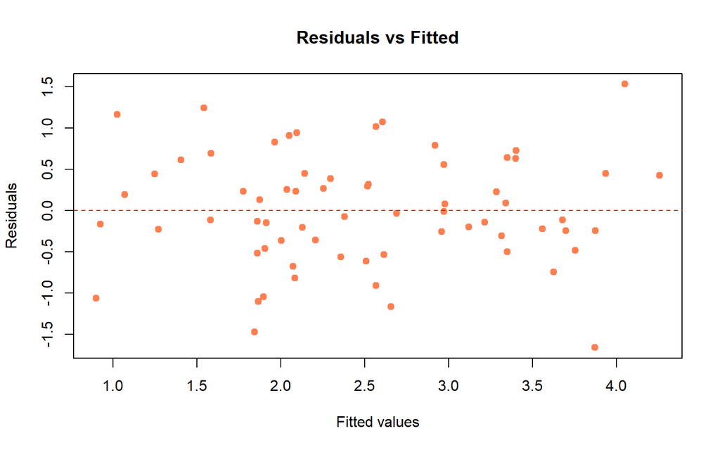

```r
plot(fitted(best_model), residuals(best_model),
     xlab = "Fitted values", ylab = "Residuals",
     main = "Residuals vs Fitted", pch = 19, col = "coral")
abline(h = 0, col = "red", lty = 2)
```

```r
bptest(best_model)
```

```
    studentized Breusch-Pagan test

data:  best_model
BP = 5.5328, df = 4, p-value = 0.2369
```

**Observations:** the residuals are randomly scattered around zero without a funnel shape, and the p-value of the Breusch-Pagan test is greater than 0.05, so $H_0$ is not rejected: the variance of the residuals is constant.

#### 6.2.3. Independence

- $H_0$: the residuals are not autocorrelated (independence).
- $H_1$: the residuals are autocorrelated.

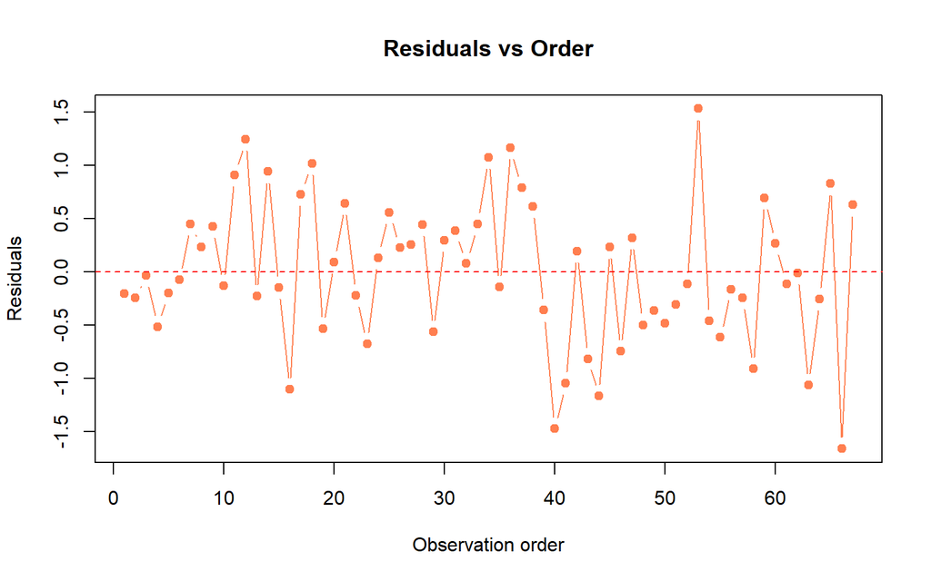

```r
plot(residuals(best_model), type = "b",
     xlab = "Observation order", ylab = "Residuals",
     main = "Residuals vs Order", pch = 19, col = "coral")
abline(h = 0, col = "red", lty = 2)
```

```r
dwtest(best_model)
```

```
    Durbin-Watson test

data:  best_model
DW = 1.9191, p-value = 0.3618
alternative hypothesis: true autocorrelation is greater than 0
```

**Observations:** the residuals show no pattern with respect to the observation order, and the Durbin-Watson statistic is close to 2 with a p-value greater than 0.05, so $H_0$ is not rejected: the residuals are independent.

## 7. Conclusions

- The Backward model, with `lcavol`, `lweight`, `svi` and `pgg45`, had the best overall performance among the variable selection methods on the test set.
- The model is globally significant according to the ANOVA F test.
- The assumptions of normality, homoscedasticity and independence of the residuals are satisfied, so the inference of the model is valid.
- The main predictor of `lpsa` is `lcavol` (the log of the cancer volume), followed by `lweight` and `svi`.